# DAT-325 Data Validation Notebook

## Instructions

In this project, you will upload the data file provided by the firm that is acquired by your company and perform some data profiling tasks to correct issues that you found in Project 2.

You will then perform some transformations to join this data set with your company's data.

### Upload data set

```python
# import Pandas and Matplotlib libraries
import pandas as pd
import matplotlib.pyplot as plt
import numpy as np



# upload firm's data
firm_data_df = pd.read_csv('DAT325_HR_Data_Firm.csv')

# report rows and columns in the data set
firm_data_shape = firm_data_df.shape
firm_data_rows, firm_data_cols = firm_data_shape[0], firm_data_shape[1]

print(f'firm data:  rows={firm_data_rows}, cols={firm_data_cols}')
```

```
firm data:  rows=105, cols=8
```

## Step 1: Data Quality for Quantitative Variables (Age)

#### 1-1 Missing Values

```python
# calculate median age
median_age = firm_data_df['Age'].median()

# fill in median age for missing values using fillna function
firm_data_df['Age'] = firm_data_df['Age'].fillna(median_age)

# validate missing values are filled
missing_value_age = firm_data_df['Age'].isnull().any()
print(f'Age has missing values after filling in the median value? {missing_value_age}\n')

# this step will print an Empty DataFrame if there are no missing values
filter_ = firm_data_df['Age'].isnull()
print(firm_data_df[filter_].to_string())
```

```
Age has missing values after filling in the median value? False

Empty DataFrame
Columns: [Employee_Name, DOB, Age, Marital_Status, Citizen_Desc, Hispanic_Latino, Race_Desc, Days_Employed]
Index: []
```

#### 1-2 Incorrect Values

```python
# remove rows with negative Age values. Assign to a new filtered dataframe
firm_data_filtered_df = firm_data_df[firm_data_df['Age']>0].copy()

# print stats for variable Age after removing negative values
stats_age = firm_data_filtered_df['Age'].describe()
print(f'\nstats Age \n{stats_age}\n')

# this step will print an Empty DataFrame if there are no negative values
filter_ = firm_data_filtered_df['Age']<0
print(firm_data_filtered_df[filter_].to_string())
```

```
stats Age
count    104.000000
mean      39.634615
std       13.159262
min       26.000000
25%       31.750000
50%       37.000000
75%       44.000000
max      139.000000
Name: Age, dtype: float64

Empty DataFrame
Columns: [Employee_Name, DOB, Age, Marital_Status, Citizen_Desc, Hispanic_Latino, Race_Desc, Days_Employed]
Index: []
```

#### 1-3 Outlier Values

```
stats Age
count    103.000000
mean      38.669903
std        8.782099
min       26.000000
25%       31.500000
50%       37.000000
75%       44.000000
max       67.000000
Name: Age, dtype: float64
```

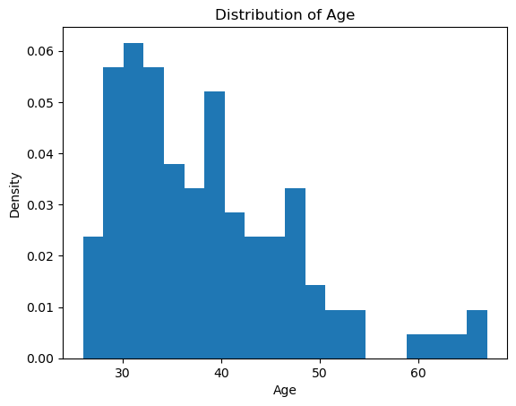

```python
# remove Age outlier value based on threshold of 110. Assign to a new filtered dataframe
firm_data_filtered2_df = firm_data_filtered_df[firm_data_filtered_df['Age']<110].copy()

# print stats for variable Age after removing negative values
stats_age = firm_data_filtered2_df['Age'].describe()
print(f'\nstats Age \n{stats_age}\n')

# validate and confirm the outlier has been removed
plt.hist(firm_data_filtered2_df['Age'], bins=20, density=True)
plt.xlabel("Age")
plt.ylabel("Density")
plt.title("Distribution of Age")
plt.show()
```

## Step 2: Data Quality for Categorical Variables (Marital Status)

#### 2-1 Missing Values

```python
# remove rows with null values. Assign to a new filtered dataframe
firm_data_filtered3_df = firm_data_filtered2_df[~firm_data_filtered2_df['Marital_Status'].isnull()].copy()

# this step will print an Empty DataFrame if there are no missing values
filter_ = firm_data_filtered3_df['Marital_Status'].isnull()
print(firm_data_filtered3_df[filter_].to_string())
```

```
Empty DataFrame
Columns: [Employee_Name, DOB, Age, Marital_Status, Citizen_Desc, Hispanic_Latino, Race_Desc, Days_Employed]
Index: []
```

#### 2-2 Incorrect Values

```python
# remove incorrect values. Assign to a new filtered dataframe
firm_data_filtered4_df = firm_data_filtered3_df[firm_data_filtered3_df['Marital_Status'].isin(['NotMarried','Married'])].copy()

# print unique values
mstatus_values = firm_data_filtered4_df['Marital_Status'].unique()
print(f'Marital Status values: {mstatus_values}')
```

```
Marital Status values: ['NotMarried' 'Married']
```

## Step 3: Data Quality (Days Employed)

#### 3-1 Missing Values

```python
firm_df = firm_data_filtered4_df.copy()
missing_days = firm_df[firm_df['Days_Employed'].isna()]
print(missing_days)
```

```
      Employee_Name        DOB   Age Marital_Status Citizen_Desc  \
52  Bramante, Elisa  3/19/1983  35.0        Married   US Citizen

   Hispanic_Latino                  Race_Desc  Days_Employed
52              No  Black or African American            NaN
```

```python
DE_Median = firm_df['Days_Employed'].median()
firm_df['Days_Employed'] = firm_df['Days_Employed'].fillna(DE_Median)
```

```python
missing_days = firm_df[firm_df['Days_Employed'].isna()]
print(missing_days)
```

```
Empty DataFrame
Columns: [Employee_Name, DOB, Age, Marital_Status, Citizen_Desc, Hispanic_Latino, Race_Desc, Days_Employed]
Index: []
```

#### 3-2 Incorrect Values

```python
print(firm_df['Days_Employed'].describe())
```

```
count       98.000000
mean      1805.030612
std       5212.593696
min       -514.000000
25%        730.500000
50%       1153.000000
75%       1860.000000
max      52246.000000
Name: Days_Employed, dtype: float64
```

```python
print(firm_df[firm_df['Days_Employed'] < 0])
```

```
      Employee_Name        DOB   Age Marital_Status Citizen_Desc  \
37  Gonzalez, Maria  4/16/1981  37.0     NotMarried   US Citizen

   Hispanic_Latino Race_Desc  Days_Employed
37             Yes     White         -514.0
```

```python
firm_df2 = firm_df[firm_df['Days_Employed'] >= 0].copy()
```

```python
print(firm_df2['Days_Employed'].describe())
```

```
count       97.000000
mean      1828.938144
std       5234.268653
min          2.000000
25%        732.000000
50%       1153.000000
75%       1881.000000
max      52246.000000
Name: Days_Employed, dtype: float64
```

#### 3-3 Outlier Values

Write your code in the line below. Be sure to use dataframe that has corrections from the previous step.

```python
print(firm_df2['Days_Employed'].nlargest(10))
```

```
89    52246.0
68     3611.0
0      3317.0
65     3244.0
72     3065.0
11     2787.0
31     2766.0
64     2686.0
32     2501.0
77     2428.0
Name: Days_Employed, dtype: float64
```

```python
#print(firm_df2['Days_Employed'].describe())
```

4000 is used as a temp threshold because only the one value of 52,000 is in that range.

```python
firm_df3 = firm_df2[firm_df2['Days_Employed']<4000].copy()
```

```python
print(firm_df3['Days_Employed'].describe())
```

```
count      96.000000
mean     1303.760417
std       806.607682
min         2.000000
25%       731.500000
50%      1153.000000
75%      1818.000000
max      3611.000000
Name: Days_Employed, dtype: float64
```

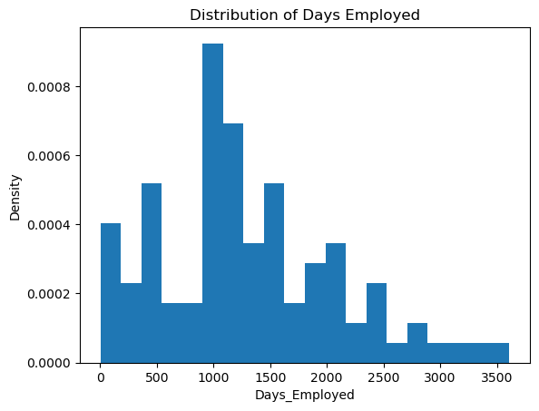

```python
plt.hist(firm_df3['Days_Employed'], bins=20, density=True)
plt.xlabel('Days_Employed')
plt.ylabel("Density")
plt.title("Distribution of Days Employed")
plt.show()
```

## Step 4: Data Quality (Citizen Description)

#### 4-1 Missing Values

```python
missing_citizen = firm_df3[firm_df3['Citizen_Desc'].isna()]
print(missing_citizen)
```

```
    Employee_Name       DOB   Age Marital_Status Citizen_Desc Hispanic_Latino  \
30  Clayton, Rick  9/5/1985  32.0        Married          NaN              No

   Race_Desc  Days_Employed
30     White         1908.0
```

```python
# remove rows with null values. Assign to a new filtered dataframe
firm_df4 = firm_df3[~firm_df3['Citizen_Desc'].isnull()].copy()
```

```python
missing_citizen = firm_df4[firm_df4['Citizen_Desc'].isna()]
print(missing_citizen)
```

```
Empty DataFrame
Columns: [Employee_Name, DOB, Age, Marital_Status, Citizen_Desc, Hispanic_Latino, Race_Desc, Days_Employed]
Index: []
```

#### 4-2 Incorrect Values

```python
print(firm_df4['Citizen_Desc'].unique())
print()
print(firm_df4[firm_df4['Citizen_Desc'] == 'Non-Citizen'])#record was already removed
print(firm_df4[firm_df4['Citizen_Desc'] == 'Male'])
```

```
['US Citizen' 'Eligible NonCitizen' 'Male']

Empty DataFrame
Columns: [Employee_Name, DOB, Age, Marital_Status, Citizen_Desc, Hispanic_Latino, Race_Desc, Days_Employed]
Index: []
     Employee_Name       DOB   Age Marital_Status Citizen_Desc  \
17  Murray, Thomas  7/4/1988  29.0        Married         Male

   Hispanic_Latino                  Race_Desc  Days_Employed
17              No  Black or African American         1112.0
```

```python
firm_df5 = firm_df4[firm_df4['Citizen_Desc'].isin(['US Citizen', 'Eligible NonCitizen'])]
```

```python
print(firm_df5['Citizen_Desc'].unique())
```

```
['US Citizen' 'Eligible NonCitizen']
```

```python
firm_df5.shape
```

```
(94, 8)
```

### DOB

```python
print(firm_df5['DOB'])
```

```
0      11/24/1987
1       4/26/1984
2        9/1/1986
3       9/16/1985
4       5/19/1988
          ...
97      4/19/1967
98     11/15/1982
100     10/7/1986
101      9/5/1991
102     5/31/1974
Name: DOB, Length: 94, dtype: object
```

```python
firm_df_plot_DOB = pd.DataFrame()
firm_df_plot_DOB['DOB'] = pd.to_datetime(firm_df5['DOB'], errors='coerce')
```

```python
df_out_DOB = firm_df_plot_DOB[(firm_df_plot_DOB['DOB'] < "1940-01-01")]
print(df_out_DOB)
```

```
          DOB
70 1919-05-22
```

```python
firm_df5.shape
```

```
(94, 8)
```

```python
#firm_df6 = firm_df5[firm_df5['DOB'].between("1940-01-01", "2030-12-31")]
firm_df6 = firm_df5.drop(firm_df5.index[70])
```

```python
firm_df6.shape
```

```
(93, 8)
```

## Hispanic Latino and Race_Desc

```python
print(firm_df6['Hispanic_Latino'].unique())
```

```
['No' 'Yes' 'yes']
```

```python
firm_df6['Hispanic_Latino'] = firm_df6['Hispanic_Latino'].str.title()
```

```python
print(firm_df6['Hispanic_Latino'].unique())
```

```
['No' 'Yes']
```

```python
print(firm_df6['Race_Desc'].unique())
```

```
['Black or African American' 'White' 'Asian' 'Two or more races'
 'Hispanic']
```

Hispanic should be moved to other column to reduce dupliaction in the dataset. We will leave it for now.

```python
firm_df6.shape
```

```
(93, 8)
```

## Step 5: Transform and Join with Your Company Data

#### 5-1 Upload Your Company’s Data

```python
# upload your company's data
your_company_data_df = pd.read_csv('DAT325_HR_Data_YourCompany.csv')

# report rows and columns in the data set
your_company_shape = your_company_data_df.shape
your_company_rows, your_company_cols = your_company_shape[0], your_company_shape[1]

print(f'your company data:  rows={your_company_rows}, cols={your_company_cols}')
```

```
your company data:  rows=105, cols=17
```

```python
#print(your_company_data_df['DOB'])
```

Both Datasets use the same date format.

#### 5-2 Data Transformation

```python
firm_data_filtered7_df = firm_df6.copy()
```

```python
# transform variable to create common variables in the two data sets
firm_data_filtered7_df[['Last_Name', 'First_Name']] = firm_data_filtered7_df['Employee_Name'].str.strip().str.split(',| ',expand=True)[[0,2]]

# use merge function in pandas to perform the merge
# fill in the appropriate variables as a list
merged_df = pd.merge(your_company_data_df, firm_data_filtered7_df, on=['Last_Name', 'First_Name', 'DOB'], how='left')

# report rows and columns in the data
merged_shape = merged_df.shape
merged_rows, merged_cols = merged_shape[0], merged_shape[1]

# report rows and columns in firm's data
firm_data_filtered7_shape = firm_data_filtered7_df.shape
firm_data_rows, firm_data_cols = firm_data_filtered7_shape[0], firm_data_filtered7_shape[1]


print(f"firm's data:  rows={firm_data_rows}, cols={firm_data_cols}")
print(f"your company data:  rows={your_company_rows}, cols={your_company_cols}")
print(f"merged data:  rows={merged_rows}, cols={merged_cols}")
```

```
firm's data:  rows=93, cols=10
your company data:  rows=105, cols=17
merged data:  rows=105, cols=24
```

```python
#with pd.option_context("display.max_rows", None,
                       #"display.max_columns", None):
    #print(merged_df)
merged_df
```

|  | Last_Name | First_Name | DOB | Employee_Number | Pay_Rate | State | Zip | Sex | Date_of_Hire | Date_of_Termination | ... | Manager_Name | Employee_Source | Performance_Score | Employee_Name | Age | Marital_Status | Citizen_Desc | Hispanic_Latino | Race_Desc | Days_Employed |
| --- | --- | --- | --- | --- | --- | --- | --- | --- | --- | --- | --- | --- | --- | --- | --- | --- | --- | --- | --- | --- | --- |
| 0 | Brown | Mia | 11/24/1987 | 1103024456 | 28.50 | MA | 1450 | Female | 10/27/2008 | NaN | ... | Brandon R. LeBlanc | Diversity Job Fair | Fully Meets | NaN | NaN | NaN | NaN | NaN | NaN | NaN |
| 1 | William | Thomas | 4/26/1984 | 1106026572 | 23.00 | MA | 1460 | Male | 1/6/2014 | NaN | ... | Brandon R. LeBlanc | Website Banner Ads | Fully Meets | NaN | NaN | NaN | NaN | NaN | NaN | NaN |
| 2 | Steans | Tyrone | 9/1/1986 | 1302053333 | 29.00 | MA | 2703 | Male | 9/29/2014 | NaN | ... | Brandon R. LeBlanc | Internet Search | Fully Meets | NaN | NaN | NaN | NaN | NaN | NaN | NaN |
| 3 | Howard | Estelle | 9/16/1985 | 1211050782 | 21.50 | MA | 2170 | Female | 2/16/2015 | 4/15/2015 | ... | Brandon R. LeBlanc | Pay Per Click - Google | N/A- too early to review | Howard, Estelle | 32.0 | NotMarried | US Citizen | No | White | 58.0 |
| 4 | Singh | Jag | 5/19/1988 | 1307059817 | 16.56 | MA | 2330 | Female | 5/1/2015 | NaN | ... | Brandon R. LeBlanc | Website Banner Ads | N/A- too early to review | NaN | NaN | NaN | NaN | NaN | NaN | NaN |
| ... | ... | ... | ... | ... | ... | ... | ... | ... | ... | ... | ... | ... | ... | ... | ... | ... | ... | ... | ... | ... | ... |
| 100 | Dobrin | Denisa | 10/7/1986 | 1202031618 | 16.75 | MA | 2125 | Female | 4/2/2012 | NaN | ... | David Stanley | Monster.com | Fully Meets | Dobrin, Denisa S | 31.0 | NotMarried | US Citizen | Yes | White | 2064.0 |
| 101 | Eaton | Marianne | 9/5/1991 | 1406067865 | 17.00 | MA | 2343 | Female | 4/4/2011 | 6/6/2013 | ... | Kissy Sullivan | Search Engine - Google Bing Yahoo | Fully Meets | Eaton, Marianne | 26.0 | Married | US Citizen | No | White | 794.0 |
| 102 | Engdahl | Jean | 5/31/1974 | 1007020403 | 21.25 | MA | 2026 | Male | 11/10/2014 | NaN | ... | Kelley Spirea | MBTA ads | Fully Meets | Engdahl, Jean | 44.0 | NotMarried | US Citizen | No | White | 1112.0 |
| 103 | England | Rex | 8/25/1978 | 1101023612 | 21.00 | MA | 2045 | Male | 3/31/2014 | NaN | ... | Kelley Spirea | Employee Referral | 90-day meets | NaN | NaN | NaN | NaN | NaN | NaN | NaN |
| 104 | Estremera | Miguel | 9/2/1983 | 1104025243 | 17.00 | MA | 2129 | Male | 4/2/2012 | 9/27/2014 | ... | Michael Albert | Word of Mouth | Needs Improvement | NaN | NaN | NaN | NaN | NaN | NaN | NaN |

105 rows × 24 columns

```python
merged_df.duplicated().any()
```

```
False
```

```python
merged_df['Employee_Name'].notna().sum()
```

```
56
```

```python
print(firm_data_filtered7_df[firm_data_filtered7_df['Last_Name'].isin(merged_df['Last_Name'])])
```

```
          Employee_Name         DOB   Age Marital_Status Citizen_Desc  \
0    Brown, Mia          11/24/1987  30.0     NotMarried   US Citizen
2      Steans, Tyrone      9/1/1986  31.0        Married   US Citizen
3       Howard, Estelle   9/16/1985  32.0     NotMarried   US Citizen
4           Singh, Nan    5/19/1988  30.0        Married   US Citizen
5      Smith, Leigh Ann   6/14/1987  30.0     NotMarried   US Citizen
..                  ...         ...   ...            ...          ...
97      Desimone, Carl    4/19/1967  51.0        Married   US Citizen
98    Dickinson, Geoff   11/15/1982  37.0     NotMarried   US Citizen
100   Dobrin, Denisa  S   10/7/1986  31.0     NotMarried   US Citizen
101     Eaton, Marianne    9/5/1991  26.0        Married   US Citizen
102       Engdahl, Jean   5/31/1974  44.0     NotMarried   US Citizen

    Hispanic_Latino                  Race_Desc  Days_Employed  Last_Name  \
0                No  Black or African American         3317.0      Brown
```

[output cut: 25 more lines]